# AllLife Credit Card Customer Segmentation

AllLife Bank wants to focus on its credit card customer base in the next financial year. They have been advised by their marketing research team, that the penetration in the market can be improved. Based on this input, the Marketing team proposes to run personalised campaigns to target new customers as well as upsell to existing customers. Another insight from the market research was that the customers perceive the support services of the back poorly. Based on this, the Operations team wants to upgrade the service delivery model, to ensure that customers queries are resolved faster. Head of Marketing and Head of Delivery both decide to reach out to the Data Science team for help

# Objective

To identify different segments in the existing customer based on their spending patterns as well as past interaction with the bank.

## Key questions to be answered -

- How many different segments of customers are there?
- How are these segments different from each other?
- What are your recommendations to the bank on how to better market to and service these customers?

**About the Dataset**

- Sl_No
- Customer Key -- Customer unique Key
- Avg_Credit_Limit -- Averageof credit limit for the customer.
- Total_Credit_Cards -- Number of credit cards customer owned from the bank.
- Total_visits_bank -- Total number of physical visits customer made with the bank.
- Total_visits_online -- Total number of visits customer made through online.
- Total_calls_made -- Total number of calls customer made to reach the bank.

```python
import warnings
warnings.filterwarnings("ignore")

#importing necessary libraries
import pandas as pd
import numpy as np
import seaborn as sns
import matplotlib.pyplot as plt

from sklearn.preprocessing import StandardScaler
from scipy.spatial.distance import cdist
from scipy.spatial.distance import pdist
from sklearn.cluster import KMeans
from sklearn.metrics import silhouette_score
from yellowbrick.cluster import KElbowVisualizer, SilhouetteVisualizer

from scipy.cluster.hierarchy import dendrogram, linkage,cophenet
from sklearn.cluster import AgglomerativeClustering
```

```python
# Reading the dataset
Custdata = pd.read_excel('Credit Card Customer Data.xlsx')
```

```python
Custdata.head()
```

|  | Sl_No | Customer Key | Avg_Credit_Limit | Total_Credit_Cards | Total_visits_bank | Total_visits_online | Total_calls_made |
| --- | --- | --- | --- | --- | --- | --- | --- |
| 0 | 1 | 87073 | 100000 | 2 | 1 | 1 | 0 |
| 1 | 2 | 38414 | 50000 | 3 | 0 | 10 | 9 |
| 2 | 3 | 17341 | 50000 | 7 | 1 | 3 | 4 |
| 3 | 4 | 40496 | 30000 | 5 | 1 | 1 | 4 |
| 4 | 5 | 47437 | 100000 | 6 | 0 | 12 | 3 |

```python
Custdata.info()
```

```
<class 'pandas.core.frame.DataFrame'>
RangeIndex: 660 entries, 0 to 659
Data columns (total 7 columns):
 #   Column               Non-Null Count  Dtype
---  ------               --------------  -----
 0   Sl_No                660 non-null    int64
 1   Customer Key         660 non-null    int64
 2   Avg_Credit_Limit     660 non-null    int64
 3   Total_Credit_Cards   660 non-null    int64
 4   Total_visits_bank    660 non-null    int64
 5   Total_visits_online  660 non-null    int64
 6   Total_calls_made     660 non-null    int64
dtypes: int64(7)
memory usage: 36.2 KB
```

- There are no missing values in the dataframe.
- There are total 7 columns and 660 observations in the dataset.

```python
Custdata.duplicated().sum()
```

```
0
```

- There are no duplicate observations in the data frame.

```python
Custdata.nunique()
```

```
Sl_No                  660
Customer Key           655
Avg_Credit_Limit       110
Total_Credit_Cards      10
Total_visits_bank        6
Total_visits_online     16
Total_calls_made        11
dtype: int64
```

```python
Custdata.duplicated('Customer Key').sum()
```

```
5
```

- There are 5 duplicates in customer key column, but the other observations are different. Will check later whether that can impact anything in the model.

```python
#dropping the serial no. column as it does not hold any statistical significance
Custdata.drop('Sl_No',axis=1,inplace=True)
```

```python
# Extracting the Attributes for the K Means model from the CustData
CustDataAttr   = Custdata.iloc[:,1:]
# Extracting the attributes for the Hierarchial clustering
HcCustDataAttr = Custdata.iloc[:,1:]
all_col = CustDataAttr.iloc[:].columns.tolist()
```

```python
CustDataAttr.describe().T
```

|  | count | mean | std | min | 25% | 50% | 75% | max |
| --- | --- | --- | --- | --- | --- | --- | --- | --- |
| Avg_Credit_Limit | 660.0 | 34574.242424 | 37625.487804 | 3000.0 | 10000.0 | 18000.0 | 48000.0 | 200000.0 |
| Total_Credit_Cards | 660.0 | 4.706061 | 2.167835 | 1.0 | 3.0 | 5.0 | 6.0 | 10.0 |
| Total_visits_bank | 660.0 | 2.403030 | 1.631813 | 0.0 | 1.0 | 2.0 | 4.0 | 5.0 |
| Total_visits_online | 660.0 | 2.606061 | 2.935724 | 0.0 | 1.0 | 2.0 | 4.0 | 15.0 |
| Total_calls_made | 660.0 | 3.583333 | 2.865317 | 0.0 | 1.0 | 3.0 | 5.0 | 10.0 |

```python
CustDataAttr.isna().sum()
```

```
Avg_Credit_Limit       0
Total_Credit_Cards     0
Total_visits_bank      0
Total_visits_online    0
Total_calls_made       0
dtype: int64
```

There are no missing values in our data

# EDA

### Univariate Analysis

- KDE plot for all the features to see how many of it can show separate clusters

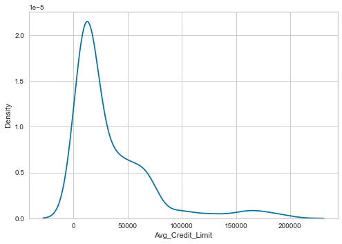

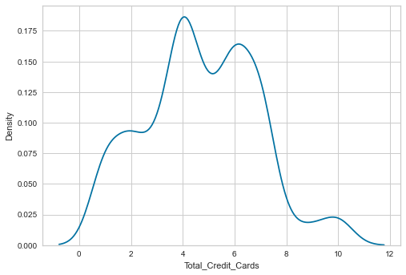

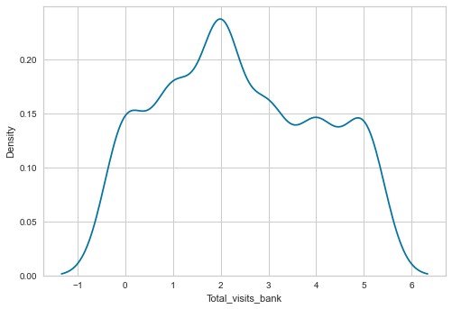

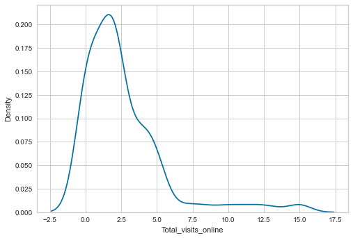

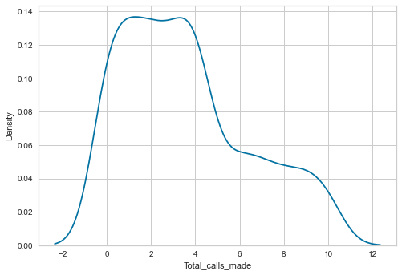

```python
for i in CustDataAttr.columns:
    sns.distplot(CustDataAttr[i],hist=False)
    plt.show()
```

- Average_Credit_limit is skewed to right side.
- Total_Visits_Online is skewed to right side.
- Total_Credit_cards infers to have 3 clusters based on the up and downs.

## Bar plot for all the features to check the feature value importance.

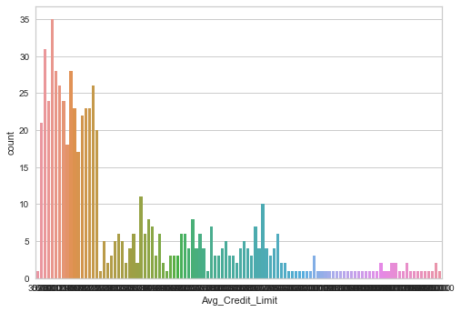

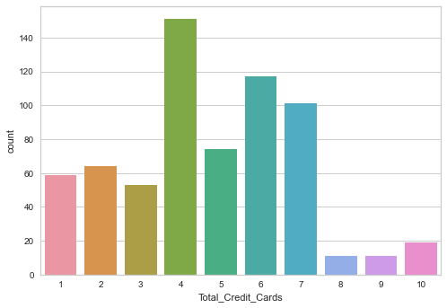

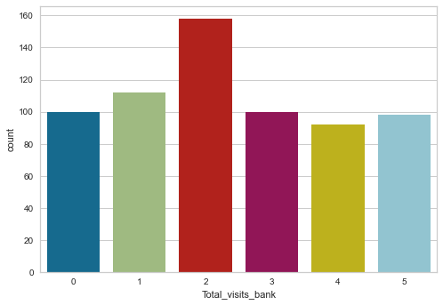

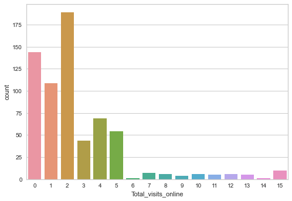

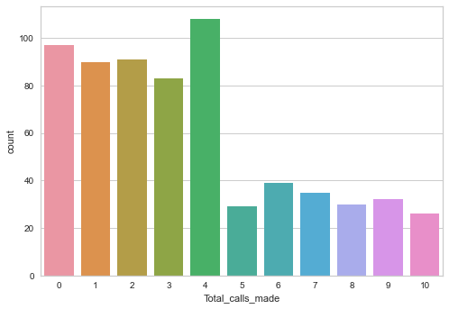

```python
# Barplot for the nuemarical variables
for i in CustDataAttr.columns:
    sns.countplot(CustDataAttr[i])
    plt.show()
```

Observations

- Total credit cards owned by customer is 4 more than the other number of credit cards owned.
- It infers most of the issues/queries are resolved when customer visited second time to the bank.
- Most of the issues/queries are resolved by second time during onine visits by the customers.
- It infers Customer has to make 3, 4 times call to the bank to resolve the issues.

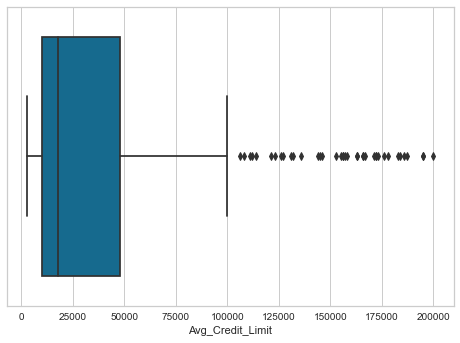

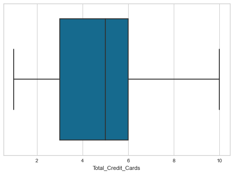

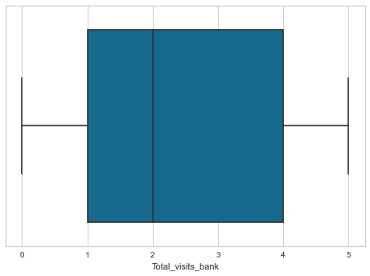

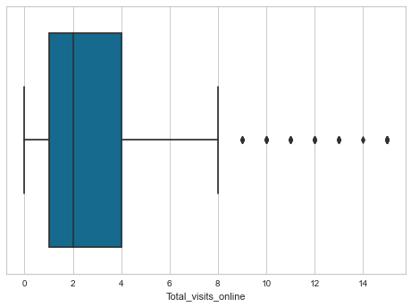

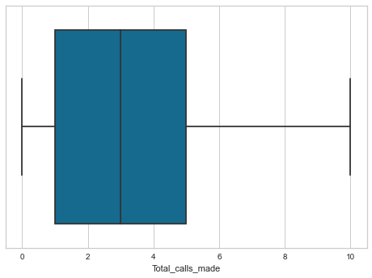

```python
# Boxplot for the nuemerical variables.
for i in CustDataAttr.columns:
    sns.boxplot(CustDataAttr[i])
    plt.show()
```

Observations

- Average_Credit_limit has more outliers on right side.
- Total_visits_Online has 7 outliers on right side.

```python
# Checking the outliers in Average_Credit_Limit and Total_Visits_Online
CustDataAttr[CustDataAttr['Avg_Credit_Limit']>100000].sort_values(by='Avg_Credit_Limit')
```

|  | Avg_Credit_Limit | Total_Credit_Cards | Total_visits_bank | Total_visits_online | Total_calls_made |
| --- | --- | --- | --- | --- | --- |
| 634 | 106000 | 8 | 0 | 8 | 1 |
| 620 | 108000 | 10 | 0 | 15 | 1 |
| 648 | 111000 | 8 | 1 | 7 | 0 |
| 649 | 112000 | 10 | 1 | 8 | 1 |
| 635 | 114000 | 10 | 1 | 7 | 2 |
| 618 | 121000 | 7 | 0 | 13 | 2 |
| 640 | 123000 | 8 | 1 | 15 | 2 |
| 636 | 126000 | 10 | 1 | 8 | 0 |
| 644 | 127000 | 10 | 1 | 15 | 1 |
| 615 | 131000 | 9 | 1 | 10 | 1 |
| 651 | 132000 | 9 | 1 | 12 | 2 |
| 617 | 136000 | 8 | 0 | 13 | 0 |
| 641 | 144000 | 10 | 0 | 10 | 2 |
| 657 | 145000 | 8 | 1 | 9 | 1 |
| 627 | 146000 | 10 | 0 | 12 | 1 |
| 638 | 153000 | 8 | 1 | 7 | 1 |
| 629 | 155000 | 8 | 0 | 7 | 2 |
| 652 | 156000 | 8 | 1 | 8 | 0 |
| 626 | 156000 | 9 | 1 | 10 | 2 |
| 612 | 157000 | 9 | 1 | 14 | 1 |
| 619 | 158000 | 7 | 0 | 13 | 0 |
| 633 | 163000 | 7 | 1 | 10 | 1 |
| 614 | 163000 | 8 | 1 | 7 | 1 |
| 621 | 166000 | 9 | 1 | 12 | 2 |
| 623 | 166000 | 10 | 0 | 7 | 0 |
| 659 | 167000 | 9 | 0 | 12 | 2 |
| 645 | 171000 | 10 | 0 | 15 | 0 |
| 658 | 172000 | 10 | 1 | 15 | 0 |
| 654 | 172000 | 10 | 1 | 9 | 1 |
| 637 | 173000 | 9 | 1 | 11 | 0 |
| 622 | 176000 | 10 | 1 | 15 | 2 |
| 624 | 178000 | 7 | 0 | 11 | 0 |
| 647 | 183000 | 9 | 0 | 9 | 2 |
| 639 | 184000 | 7 | 1 | 15 | 2 |
| 646 | 186000 | 7 | 0 | 8 | 1 |
| 632 | 187000 | 7 | 1 | 7 | 0 |
| 631 | 195000 | 8 | 0 | 15 | 0 |
| 650 | 195000 | 10 | 1 | 12 | 2 |
| 630 | 200000 | 10 | 0 | 13 | 0 |

- There is one observation that has Max Avg_credit_limit of 200000, but the other features realted to this customer does have meaning full information for the model.

```python
# Checking the outliers in Average_Credit_Limit and Total_Visits_Online
CustDataAttr[CustDataAttr['Total_visits_online']>8].sort_values(by='Total_visits_online')
```

|  | Avg_Credit_Limit | Total_Credit_Cards | Total_visits_bank | Total_visits_online | Total_calls_made |
| --- | --- | --- | --- | --- | --- |
| 657 | 145000 | 8 | 1 | 9 | 1 |
| 642 | 97000 | 10 | 1 | 9 | 2 |
| 647 | 183000 | 9 | 0 | 9 | 2 |
| 654 | 172000 | 10 | 1 | 9 | 1 |
| 1 | 50000 | 3 | 0 | 10 | 9 |
| 626 | 156000 | 9 | 1 | 10 | 2 |
| 641 | 144000 | 10 | 0 | 10 | 2 |
| 633 | 163000 | 7 | 1 | 10 | 1 |
| 615 | 131000 | 9 | 1 | 10 | 1 |
| 655 | 99000 | 10 | 1 | 10 | 0 |
| 637 | 173000 | 9 | 1 | 11 | 0 |
| 613 | 94000 | 9 | 1 | 11 | 0 |
| 624 | 178000 | 7 | 0 | 11 | 0 |
| 6 | 100000 | 5 | 0 | 11 | 2 |
| 616 | 96000 | 10 | 1 | 11 | 2 |
| 650 | 195000 | 10 | 1 | 12 | 2 |
| 651 | 132000 | 9 | 1 | 12 | 2 |
| 659 | 167000 | 9 | 0 | 12 | 2 |
| 4 | 100000 | 6 | 0 | 12 | 3 |
| 627 | 146000 | 10 | 0 | 12 | 1 |
| 621 | 166000 | 9 | 1 | 12 | 2 |
| 656 | 84000 | 10 | 1 | 13 | 2 |
| 617 | 136000 | 8 | 0 | 13 | 0 |
| 618 | 121000 | 7 | 0 | 13 | 2 |
| 630 | 200000 | 10 | 0 | 13 | 0 |
| 619 | 158000 | 7 | 0 | 13 | 0 |
| 612 | 157000 | 9 | 1 | 14 | 1 |
| 658 | 172000 | 10 | 1 | 15 | 0 |
| 653 | 95000 | 10 | 0 | 15 | 1 |
| 620 | 108000 | 10 | 0 | 15 | 1 |
| 644 | 127000 | 10 | 1 | 15 | 1 |
| 622 | 176000 | 10 | 1 | 15 | 2 |
| 640 | 123000 | 8 | 1 | 15 | 2 |
| 639 | 184000 | 7 | 1 | 15 | 2 |
| 628 | 84000 | 9 | 1 | 15 | 0 |
| 645 | 171000 | 10 | 0 | 15 | 0 |
| 631 | 195000 | 8 | 0 | 15 | 0 |

- There are 10 observations that has total_visits_online has 15, Not droping this data as we have very less number of observations.

### Bivariate Analsysis

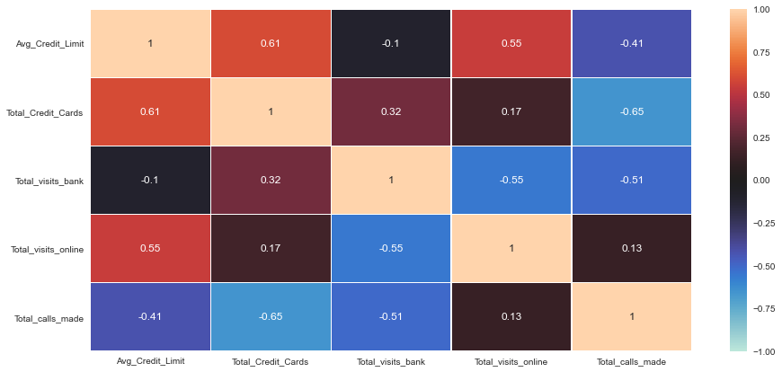

```python
# Heat map for the attributes
plt.figure(figsize=(15,7))

sns.heatmap(CustDataAttr.corr(),
            annot=True,
            linewidths=0.5,vmin=-1,vmax=1,
            center=0,
            cbar=True,)

plt.show()
```

**Observation**

- Avg_Credit_Limit has positive correlation with Total_Credit_Cards as well as with Total_Visits_Online, which is obvious that Customers who has more number of credit cards has more Avg credit limit.
- Total_Credit_Cards has Negative correlation with the total_calls_made, i.e customer having more number of credit cards are able to rsolve issue on thier own.

## pairplots for the features.

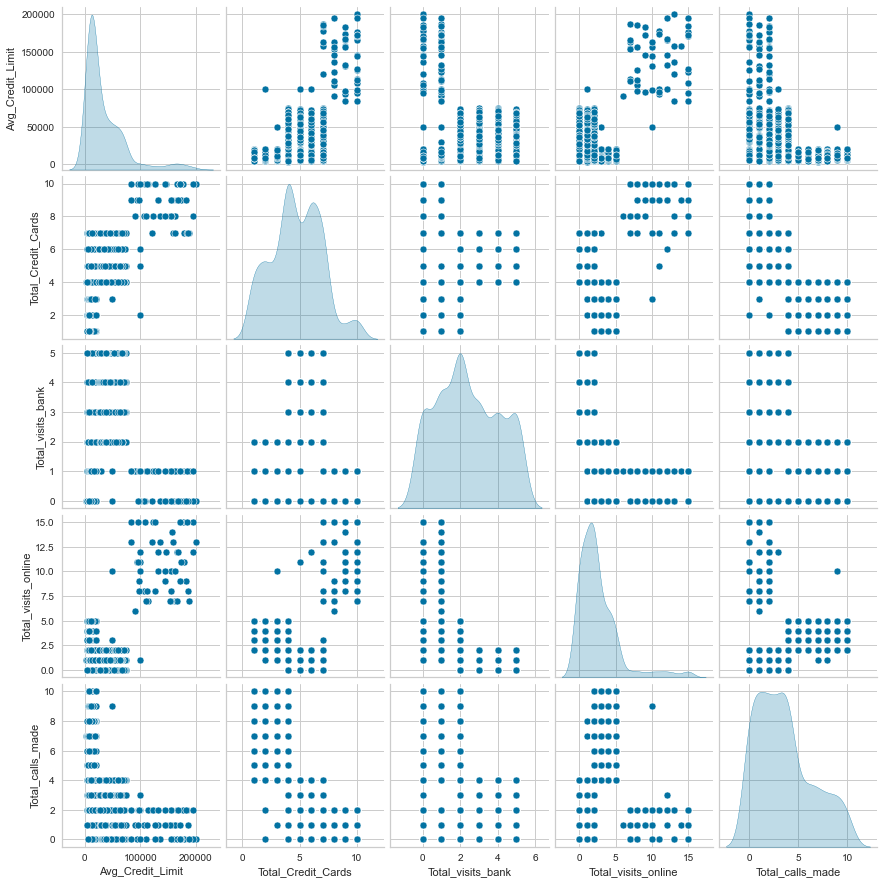

```python
# Pairplot for
sns.pairplot(CustDataAttr,diag_kind="kde")
```

**Observations**

- Avg_Credit_Limit is negaivly correlated with Total_Calls_made, When the credit limit increases total_calls_made diminishing.
- Total_Credit_Cards is negatively correlated with Total_Calls_Made, when the customer owns more number of credit cards they are able to resolve the issue on thier own.
- Total_Visits_Online is positively correlated with Avg_Credit_Limit and Total_Credit_Cards, it is obvious that when customer has more credit cards that tends to make mroe online visits to check the transactions.
- Distribution of Total_Calls_Made is bimodal.

```python
# Scaling the data set before clustering
scaler=StandardScaler()
subset=CustDataAttr.copy()
subset_scaled=scaler.fit_transform(subset)
```

```python
#Creating a dataframe from the scaled data above
subset_scaled_df=pd.DataFrame(subset_scaled,columns=subset.columns)
```

```python
subset_scaled_df.head()
```

|  | Avg_Credit_Limit | Total_Credit_Cards | Total_visits_bank | Total_visits_online | Total_calls_made |
| --- | --- | --- | --- | --- | --- |
| 0 | 1.740187 | -1.249225 | -0.860451 | -0.547490 | -1.251537 |
| 1 | 0.410293 | -0.787585 | -1.473731 | 2.520519 | 1.891859 |
| 2 | 0.410293 | 1.058973 | -0.860451 | 0.134290 | 0.145528 |
| 3 | -0.121665 | 0.135694 | -0.860451 | -0.547490 | 0.145528 |
| 4 | 1.740187 | 0.597334 | -1.473731 | 3.202298 | -0.203739 |

## KMeans Clustering

```
Wall time: 0 ns
Number of Clusters: 1 	Average Distortion: 2.0069222262503614
Number of Clusters: 2 	Average Distortion: 1.4571553548514269
Number of Clusters: 3 	Average Distortion: 1.1466276549150365
Number of Clusters: 4 	Average Distortion: 1.0463825294774465
Number of Clusters: 5 	Average Distortion: 0.9907863827388572
Number of Clusters: 6 	Average Distortion: 0.942954855811611
Number of Clusters: 7 	Average Distortion: 0.9091362001500471
Number of Clusters: 8 	Average Distortion: 0.8890868318901024
Number of Clusters: 9 	Average Distortion: 0.8668661214508095
```

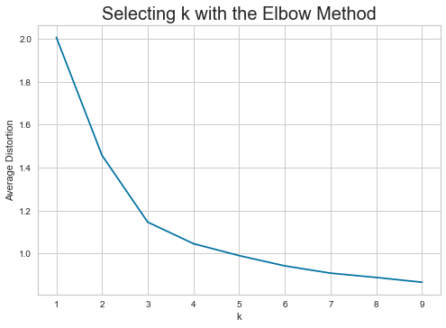

```python
%time
clusters=range(1,10)
meanDistortions=[]

for k in clusters:
    model=KMeans(n_clusters=k)
    model.fit(subset_scaled_df)
    prediction=model.predict(subset_scaled_df)
    distortion=sum(np.min(cdist(subset_scaled_df, model.cluster_centers_, 'euclidean'), axis=1)) / subset_scaled_df.shape[0]

    meanDistortions.append(distortion)

    print('Number of Clusters:', k, '\tAverage Distortion:', distortion)

plt.plot(clusters, meanDistortions, 'bx-')
plt.xlabel('k')
plt.ylabel('Average Distortion')
plt.title('Selecting k with the Elbow Method', fontsize=20)
```

The appropriate value of k from elbow curve seems to be 4 or 5 , distortion start decreasing in linear fasion.

### Lets us check silhoutte score

```python
sil_score = []
cluster_list = list(range(2,10))
for n_clusters in cluster_list:
    clusterer = KMeans(n_clusters=n_clusters)
    preds = clusterer.fit_predict((subset_scaled_df))
    #centers = clusterer.cluster_centers_
    score = silhouette_score(subset_scaled_df, preds)
    sil_score.append(score)
    print("For n_clusters = {}, silhouette score is {})".format(n_clusters, score))
```

```
For n_clusters = 2, silhouette score is 0.41842496663215445)
For n_clusters = 3, silhouette score is 0.5157182558881063)
For n_clusters = 4, silhouette score is 0.3556670619372605)
For n_clusters = 5, silhouette score is 0.2717470361089752)
For n_clusters = 6, silhouette score is 0.25583657571102003)
For n_clusters = 7, silhouette score is 0.24857757667769284)
For n_clusters = 8, silhouette score is 0.22849668591659045)
For n_clusters = 9, silhouette score is 0.21266293696549737)
```

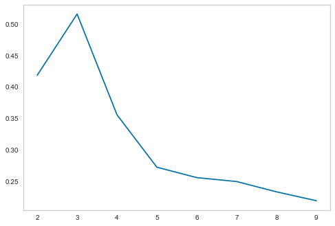

```python
plt.plot(cluster_list,sil_score)
plt.grid()
```

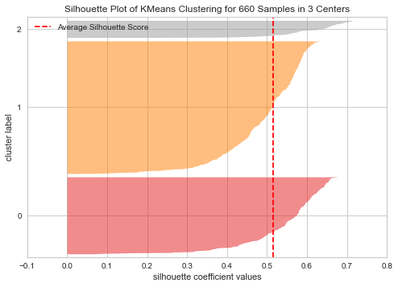

```python
#Finding optimal no. of clusters with silhouette coefficients
visualizer = SilhouetteVisualizer(KMeans(3, random_state = 1))
visualizer.fit(subset_scaled_df)
visualizer.show()
```

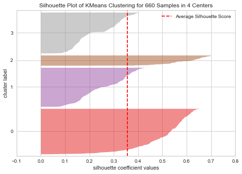

```python
#Finding optimal no. of clusters with silhouette coefficients
visualizer = SilhouetteVisualizer(KMeans(4, random_state = 1))
visualizer.fit(subset_scaled_df)
visualizer.show()
```

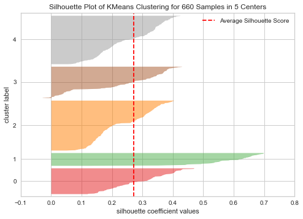

```python
#Finding optimal no. of clusters with silhouette coefficients
visualizer = SilhouetteVisualizer(KMeans(5, random_state = 1))
visualizer.fit(subset_scaled_df)
visualizer.show()
```

### Let us take 5 as appropriate no. of clusters as silhoutte score is high enough and there is a linear decrease in distortion at 5 in elbow curve.

```python
kmeans = KMeans(n_clusters=5, random_state=0)
kmeans.fit(subset_scaled_df)
```

```
KMeans(n_clusters=5, random_state=0)
```

```python
CustDataAttr['K_means_segments'] = kmeans.labels_
```

```python
# Porfiling of the data.
Kcluster_profile = CustDataAttr.groupby('K_means_segments').mean()
```

```python
Kcluster_profile['count_in_each_segment'] = CustDataAttr.groupby('K_means_segments')['Avg_Credit_Limit'].count().values
```

```python
Kcluster_profile.style.highlight_max(color = 'lightgreen', axis = 0)
```

| K_means_segments | Avg_Credit_Limit | Total_Credit_Cards | Total_visits_bank | Total_visits_online | Total_calls_made | count_in_each_segment |
| --- | --- | --- | --- | --- | --- | --- |
| 0 | 12300.813008 | 2.357724 | 0.878049 | 3.626016 | 8.398374 | 123 |
| 1 | 31226.315789 | 5.478947 | 4.515789 | 1.010526 | 1.936842 | 190 |
| 2 | 141040.000000 | 8.740000 | 0.600000 | 10.900000 | 1.080000 | 50 |
| 3 | 12019.801980 | 2.475248 | 1.000000 | 3.465347 | 5.009901 | 101 |
| 4 | 36260.204082 | 5.551020 | 2.494898 | 0.954082 | 2.061224 | 196 |

## Hierarchial clustering

```python
%time
# cophenet index is a measure of the correlation between the distance of points in feature space and distance on dendrogram
distance_metrics = [ 'euclidean','chebyshev','mahalanobis','cityblock']
linkage_methods = ['single', 'complete', 'average', 'weighted']
high_cophenet_corr = 0
high_dm_lm = [0,0]
for dm in distance_metrics:
    for lm in linkage_methods:
        Z = linkage(subset_scaled_df, metric=dm, method=lm)
        c, coph_dists = cophenet(Z , pdist(subset_scaled_df))
        print('Cophent correlation for distance metrics {} and linkage method {} is {}'.format(dm,lm,c))
        if high_cophenet_corr < c:
            high_cophenet_corr = c
            high_dm_lm[0] = dm
            high_dm_lm[1] = lm
print('Highest cophenet correlation is {}, which is obtinaed with {} distance metric and {} linkage method'.format(high_cophenet_corr ,high_dm_lm[0],high_dm_lm[1]))
```

```
Wall time: 0 ns
Cophent correlation for distance metrics euclidean and linkage method single is 0.7391220243806552
Cophent correlation for distance metrics euclidean and linkage method complete is 0.8599730607972423
Cophent correlation for distance metrics euclidean and linkage method average is 0.8977080867389372
Cophent correlation for distance metrics euclidean and linkage method weighted is 0.8861746814895477
Cophent correlation for distance metrics chebyshev and linkage method single is 0.7382354769296767
Cophent correlation for distance metrics chebyshev and linkage method complete is 0.8533474836336782
Cophent correlation for distance metrics chebyshev and linkage method average is 0.8974159511838106
Cophent correlation for distance metrics chebyshev and linkage method weighted is 0.8913624010768603
Cophent correlation for distance metrics mahalanobis and linkage method single is 0.7058064784553606
Cophent correlation for distance metrics mahalanobis and linkage method complete is 0.5422791209801747
Cophent correlation for distance metrics mahalanobis and linkage method average is 0.8326994115042134
Cophent correlation for distance metrics mahalanobis and linkage method weighted is 0.7805990615142516
Cophent correlation for distance metrics cityblock and linkage method single is 0.7252379350252723
Cophent correlation for distance metrics cityblock and linkage method complete is 0.8731477899179829
Cophent correlation for distance metrics cityblock and linkage method average is 0.896329431104133
Cophent correlation for distance metrics cityblock and linkage method weighted is 0.8825520731498188
Highest cophenet correlation is 0.8977080867389372, which is obtinaed with euclidean distance metric and average linkage method
```

- Lets explore 'centroid', 'median','ward' linkage method which requires only Euclidean distance metrics

```python
%time
linkage_methods = ['single', 'centroid','complete', 'average','median','ward', 'weighted']
high_cophenet_corr = 0
high_dm_lm = [0,0]

for lm in linkage_methods:
    Z = linkage(subset_scaled_df, metric='euclidean', method=lm)
    c, coph_dists = cophenet(Z , pdist(subset_scaled_df))
    print('Cophent correlation for distance metrics {} and linkage method {} is {}'.format('euclidean',lm,c))
    if high_cophenet_corr < c:
        high_cophenet_corr = c
        high_dm_lm[0] = dm
        high_dm_lm[1] = lm
print('*'*110)
print('Highest cophenet correlation is {}, which is obtinaed with {} distance metric and {} linkage method'.format(high_cophenet_corr ,'euclidean',high_dm_lm[1]))
```

```
Wall time: 0 ns
Cophent correlation for distance metrics euclidean and linkage method single is 0.7391220243806552
Cophent correlation for distance metrics euclidean and linkage method centroid is 0.8939385846326323
Cophent correlation for distance metrics euclidean and linkage method complete is 0.8599730607972423
Cophent correlation for distance metrics euclidean and linkage method average is 0.8977080867389372
Cophent correlation for distance metrics euclidean and linkage method median is 0.8893799537016724
Cophent correlation for distance metrics euclidean and linkage method ward is 0.7415156284827493
Cophent correlation for distance metrics euclidean and linkage method weighted is 0.8861746814895477
Highest cophenet correlation is 0.8977080867389372, which is obtinaed with euclidean distance metric and average linkage method
```

Observations

. we see that cophenet index is maximum with euclidean distance metric with average linkage method. . Lets see the dendrogram of different linkage method

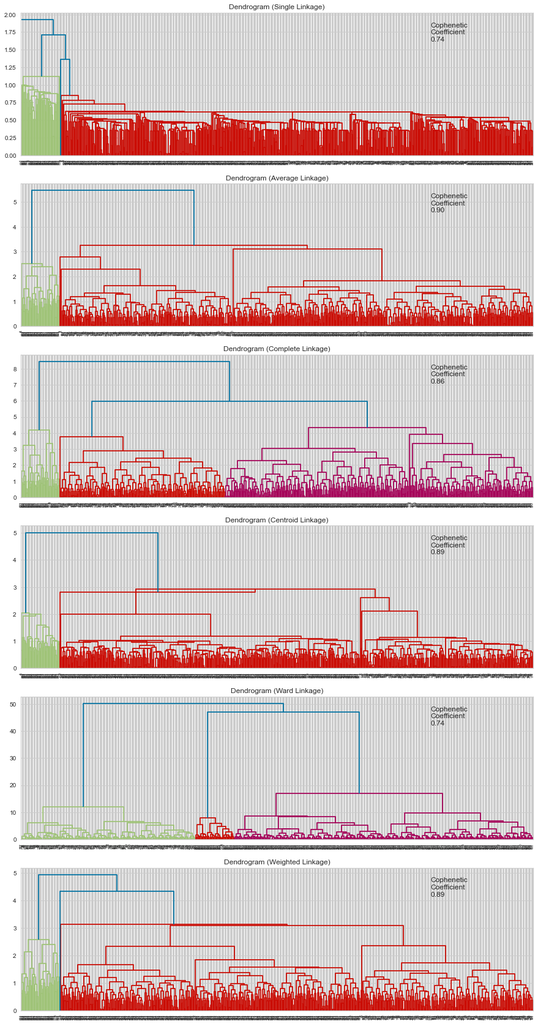

```python
# List of all linkage methods to check
methods = ['single',
           'average',
           'complete',
           'centroid',
           'ward',
           'weighted']

# Calculate the pairwise distance form the dataset to be used in the cophenetic correlation calculation
#pw_distance = pdist(credit_scaled)

# Create lists to save results of coph calculation
compare_cols = ['Linkage', 'Cophenetic Coefficient']
compare = []

# Create a subplot image
fig, axs = plt.subplots(len(methods), 1, figsize=(15, 30))

# Enumerate through the list of all methods above
# Get linkage, plot dendrogram, calculate cophenetic coefficient
for i, method in enumerate(methods):

    Z = linkage(subset_scaled_df, metric='euclidean', method=method)

    dendrogram(Z, ax=axs[i]);
    axs[i].set_title(f'Dendrogram ({method.capitalize()} Linkage)')
    coph_corr, coph_dist = cophenet(Z, pdist(subset_scaled_df))
    axs[i].annotate(f'Cophenetic\nCoefficient\n{coph_corr:0.2f}',
                    (0.80, 0.80),
                    xycoords='axes fraction')
    compare.append([method, coph_corr])
```

- Observations

Dendrogram with ward linkage method shows distinct and separate cluster

```python
# Create and print dataframe to compare Cophenetic Coefficient for each linkage
df_cc = pd.DataFrame(compare, columns=compare_cols)
df_cc
```

|  | Linkage | Cophenetic Coefficient |
| --- | --- | --- |
| 0 | single | 0.739122 |
| 1 | average | 0.897708 |
| 2 | complete | 0.859973 |
| 3 | centroid | 0.893939 |
| 4 | ward | 0.741516 |
| 5 | weighted | 0.886175 |

- Observations
- Out of all the dendrogram we saw, it is clear that cophenet index is maximum with euclidean distance metric with average  
  linkage method.
- 4 cluster would be appropriate number of cluster from dendrogram with ward linkage method

```python
#Trying with K value as 3
HCmodel = AgglomerativeClustering(n_clusters=4,affinity='euclidean', linkage='ward')
HCmodel.fit(subset_scaled_df)
subset_scaled_df['HC_Clusters'] = HCmodel.labels_
```

```python
HcCustDataAttr['HC_Clusters'] = HCmodel.labels_
```

```python
# Porfiling for Hierarchial clustering
Hcluster_profile = HcCustDataAttr.groupby('HC_Clusters').mean()
```

```python
Hcluster_profile['count_in_each_segments'] = HcCustDataAttr.groupby('HC_Clusters')['Avg_Credit_Limit'].count().values
```

```python
# lets display cluster profile
Hcluster_profile.style.highlight_max(color = 'lightgreen', axis = 0)
```

| HC_Clusters | Avg_Credit_Limit | Total_Credit_Cards | Total_visits_bank | Total_visits_online | Total_calls_made | count_in_each_segments |
| --- | --- | --- | --- | --- | --- | --- |
| 0 | 12151.111111 | 2.422222 | 0.937778 | 3.546667 | 6.857778 | 225 |
| 1 | 38298.429319 | 5.670157 | 2.523560 | 0.947644 | 2.099476 | 191 |
| 2 | 141040.000000 | 8.740000 | 0.600000 | 10.900000 | 1.080000 | 50 |
| 3 | 29474.226804 | 5.365979 | 4.448454 | 1.010309 | 1.891753 | 194 |

# Comparision between kMeans and Hierarchical clustering.

For this problem statement, not seeing much diffeence in computation time as we are dealing with small set of data.

By comparing the Kmeans and Hierarchical clustering, prefer to go with Kmeans elbow curve with 5 clusters to get the optimal usage of clustering.

```python
# Profiling the Kmeans clustering
Kcluster_profile.style.highlight_max(color = 'lightgreen', axis = 0)
```

| K_means_segments | Avg_Credit_Limit | Total_Credit_Cards | Total_visits_bank | Total_visits_online | Total_calls_made | count_in_each_segment |
| --- | --- | --- | --- | --- | --- | --- |
| 0 | 12300.813008 | 2.357724 | 0.878049 | 3.626016 | 8.398374 | 123 |
| 1 | 31226.315789 | 5.478947 | 4.515789 | 1.010526 | 1.936842 | 190 |
| 2 | 141040.000000 | 8.740000 | 0.600000 | 10.900000 | 1.080000 | 50 |
| 3 | 12019.801980 | 2.475248 | 1.000000 | 3.465347 | 5.009901 | 101 |
| 4 | 36260.204082 | 5.551020 | 2.494898 | 0.954082 | 2.061224 | 196 |

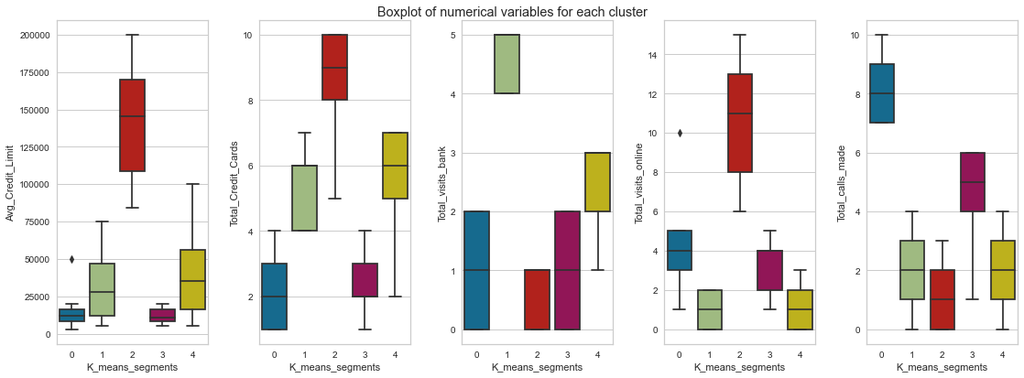

```python
fig, axes = plt.subplots(1, 5,  figsize=(16, 6))
fig.suptitle('Boxplot of numerical variables for each cluster')
counter = 0
for ii in range(5):
    sns.boxplot(ax=axes[ii],y=CustDataAttr[all_col[counter]],x=CustDataAttr['K_means_segments'])
    counter = counter+1

fig.tight_layout(pad=2.0)
```

**Insights**

- Clusters 0 :
  - Avarage Credit Limit is low with a median of 10000, that implies customers having very low credit  
    limit credit cards.
  - Number of credit cards customers having are very low with a median of 2, that implies customers are having less number of relationships with the bank.
  - Total visits to the bank are in between 0 and 2 with a median of 1, Customer visits to the bank are less.
  - Total Visits Online has a median of 4, infers customers prefer to visit online banking than visit to the bank.
  - Total Calls made are high and having a median of 8, that infers customers prefer to make a call to the bank to resolve  
    the issues than personal visits as well as online bank visits.
- Cluster 1 :
  - Avarage Credit Limit is low with a median of 30000, that implies most of the customers are are having low credit limit on their credit cards.
  - Total number of credit cards customer haivng are is low to medium between 4 and 7.
  - Number of visits customer made to the bank is high, it infers customer prefer to visit the bank in this cluster.
  - Total Visits Online is very low with a median of 1, that infers customer doesn't like to use online portals to reach out to the bank.
  - Total calls made to the bank are low, has a median of 2.
  - Customers in this segment prefer to make a visit to the bank than online visits as well as with phone calls.
- Cluster 2 :
  - Avarage Credit Limit is high with a median of 145000, that implies most of the customers are are having high credit limit on their credit cards.
  - Total number of credit cards customer haivng are is high with a median of 9, implies customers are having good  
    relationships with the bank.
  - Number of visits customer made to the bank is very low.
  - Total Visits Online is very high with a median of 11, that infers customers like to use online portals to reach out to the bank.
  - Total calls made to the bank are very low, has a median of 1.
  - Customers in this segment prefer to use online banking to rsolve all thier issues.
- Cluster 3 :
  - Avarage Credit Limit is very low with a median of 8000, that implies customers having very low credit  
    limit credit cards.
  - Number of credit cards customers having are low.
  - Total visits to the bank are very low, infers Customer visits to the bank are less.
  - Total Visits Online are low.
  - Total Calls made are low to medium with a median of 5.
  - Customers in this segment prefer to make a call to the bank to resolve the issues than personal visits as well as online bank visits.
- Cluster 4 :
  - Avarage Credit Limit is low to medium, that implies customers are having good credit limit credit cards.
  - Number of credit cards customers having are medium to hihg with median of 6, infers customers are having good  
    relationships with the bank.
  - Total visits to the bank are low to medium, infers Customer visits to the bank are high.
  - Total Visits Online are low with a median of 1.
  - Total Calls made are low with the median of 2.
  - Customers in this segment prefer to visit the bank thans than online visits as well as phone calls to the bank.

### Business recommendation

- Cluster 0
  - Marketing team can develop a campaign to reach out this segment to upsell the products as the customers are having very less credit limit as well as less number of credit cards with the bank.
  - Customers in this segment are making lot of calls to get the resolution for the issues, operations team has to come up with a strategy to resolve the issues with in the first or second call to improve the customer expericene.
- Cluster 1
  - Marketing team can come up with a strategy about offering higher credit card limits by upselling the higher limit credit cards.
  - Customers in this segment are making lot of personal visits to the bank to resolve/completing thier trasactions. Operations team has to focus on what is causing the clients to make the personal visits to the bank. They have to build a strategy to improve the customer experience by making them to resolve the issues either through online portal or customer service call.
- Cluster 2
  - Customers in this segment are having higher credit limit as well as more number of credit cards and they are the ones  
    generting more revenue to the bank. Marketing team can build a strategy by about how to retain these customers by giving additional incentives on the credit cards.
  - Customers are mainly dependent on online portals to perform the transactions/resolve the issues, operations team has to focus more on how to improve the online experience by providing exhaustive information and search capabilities and for the  
    customers on this segment.
- Cluster 3
  - Marketing team can develop a campaign to reach out this segment to upsell the products as the customers are having very less credit limit as well as less number of credit cards with the bank.
  - Customers in this segment are making moderate number of calls to get the resolution for their issues, operations team has to come up with a strategy to resolve the issues with in the first or second call to improve the customer expericene.
- Cluster 4
  - Customers in this segment are having lower credit limits but owning good number of credit cards with the bank, Marketing team has to focus on building a campaign to upsell the credit cards that has more credit limits.
  - Customers in this segment are making moderate number of personal visits to the bank to resolve the issues/complete the  
    transactions. Operations team has check the past data to seek how the bank can help these customers segments to find the resolution through online or customer srvice calls instead of making personal visits to the bank. Making a personal visit to the bank is always expensie to both the customer as well as to bank.